**Author**: Imene DERRAR · **Supervisor**: Dr. Abdelillah OTMANE CHERIF  
**Institutions**: NHSM — National Higher School of Mathematics · IHFR — Institut Hydrométéorologique de Formation et de Recherche  
**Academic year**: 2025–2026  
**Project**: Final-year engineering thesis in Applied Mathematics — Specialization: Statistics, Econometrics and Actuarial Science — Drought modelling and probabilistic forecasting for the Chélif basin

# Notebook E.2 --- Master precipitation panel and period selection

**Thesis support.** Chapter 3 (Data Engineering and Index Construction), §3.4--§3.5

**Purpose.** Builds the master precipitation panel by reconciling the three IHFR-delivered sub-archives ingested in notebook E.1, and evaluates five candidate analytical windows against the C1/C2/C3 eligibility filter to select the 1990--2015 window retained throughout the thesis.

**Main inputs.** Per-station CSVs produced by notebook E.1 (`phase00_ingest_ihfr_onm.py`); the station-identifier reconciliation table.

**Main outputs.** Master precipitation panel (32 stations, monthly long format); period-comparison table referenced as Table 3.5 in the thesis.

**Dependencies.** Requires notebook E.1 to have been run first.

**Execution notes.** All code cells in this notebook have been executed and their outputs (figures, tables, diagnostics) are saved inline. A re-run from a clean kernel should reproduce these outputs given the same input data, with the caveats listed in Appendix B of the thesis (reproducibility and computational environment).

# Notebook `E2_data_audit_and_structuring`

**Thesis:** Drought Modeling and Probabilistic Forecasting in the Chélif Basin (Algeria)  
**Stage:** Data Engineering — Audit, Structuring, and Study Period Selection

## Role in the pipeline

This notebook serves as the **diagnostic and structuring foundation** of the entire precipitation workflow. Before any drought index can be constructed and before any model can be fitted, the raw observational material must be rigorously characterised: its structure must be understood, its deficiencies must be quantified, and the analysis window must be chosen on empirical grounds rather than assumed.

This notebook answers three questions:

1. **What is the actual structure and quality of the raw data?** (Sections 1–8)
2. **What is the true missingness landscape once implicit gaps are made explicit?** (Sections 9–10)
3. **Over which time window does the network provide the strongest statistical basis for SPI construction?** (Sections 11–13)

The answer to question 3 — the **recommended study period** — is a data-driven decision, not an assumption. It is derived from an explicit multi-criteria comparison of candidate windows and is documented here in a form suitable for thesis justification.

## What this notebook does NOT do

| ❌ Forbidden | Rationale |
| --- | --- |
| Interpolation | Imputed values must not enter the missing-data audit |
| Station filtering | Selection criteria belong in `E3_data_preprocessing_and_station_selection.ipynb` |
| SPI computation | Requires a gap-free dataset that does not yet exist here |
| Gamma fitting | Downstream operation |
| Silent data deletion | Every transformation must be logged |

## Section 0 — Setup

Paths are constructed with `pathlib.Path` for cross-platform reproducibility. The `NOTEBOOK_NAME` constant drives the output folder naming — all outputs of this notebook are written to a dedicated stage-specific folder, ensuring no file from this notebook can be confused with outputs from another stage.

```python
# ── Standard library ──────────────────────────────────────────────────────────
from pathlib import Path
import warnings
warnings.filterwarnings("ignore")

# ── Third-party ───────────────────────────────────────────────────────────────
import numpy as np
import pandas as pd
import matplotlib.pyplot as plt
import matplotlib.patches as mpatches
import matplotlib.ticker as mticker
import seaborn as sns

# ── Display settings ──────────────────────────────────────────────────────────
pd.set_option("display.max_columns", 25)
pd.set_option("display.max_rows", 100)
pd.set_option("display.float_format", "{:.4f}".format)
pd.set_option("display.width", 130)
sns.set_theme(style="whitegrid", palette="muted", font_scale=1.05)
plt.rcParams["figure.dpi"] = 120
plt.rcParams["savefig.bbox"] = "tight"

# ── Notebook identity ─────────────────────────────────────────────────────────
NOTEBOOK_NAME = "00_data_audit_and_structuring"

# ── Project paths ─────────────────────────────────────────────────────────────
BASE_DIR = Path(os.environ.get("CHELIF_BASE_DIR", Path.cwd()))
DATA_DIR = BASE_DIR / "01_data"
OUT_DIR  = BASE_DIR / "03_outputs" / NOTEBOOK_NAME
OUT_DIR.mkdir(parents=True, exist_ok=True)

# ── Input files ───────────────────────────────────────────────────────────────
F_PRECIP = DATA_DIR / "master_precipitation_final_plus_pluvio.csv"
F_META   = DATA_DIR / "master_station_metadata_final_plus_pluvio.csv"
F_COPERN = DATA_DIR / "copernicus_regional_monthly_chelif_1989_2019.csv"

# ── Canonical column names ────────────────────────────────────────────────────
STATION_COL = "master_station_id"
DATE_COL    = "date"
PRECIP_COL  = "precip_mm"

# ── Path verification ─────────────────────────────────────────────────────────
print("Path check:")
for label, p in [("Data dir",  DATA_DIR),  ("Output dir", OUT_DIR),
                 ("Precip",    F_PRECIP),   ("Meta",       F_META),
                 ("Copernicus",F_COPERN)]:
    flag = "✓" if p.exists() else "✗  NOT FOUND"
    print(f"  [{flag}]  {label}: {p}")
```

```
Path check:
  [✓]  Data dir: <project_root>\01_data
  [✓]  Output dir: <project_root>\03_outputs\00_data_audit_and_structuring
  [✓]  Precip: <project_root>\01_data\master_precipitation_final_plus_pluvio.csv
  [✓]  Meta: <project_root>\01_data\master_station_metadata_final_plus_pluvio.csv
  [✓]  Copernicus: <project_root>\01_data\copernicus_regional_monthly_chelif_1989_2019.csv
```

## Section 1 — Load Raw Datasets

Three files are loaded at this stage:

> **Note on file exclusion**: `spi_ready_dataset_main_1990_2015.csv` is a *downstream product* of the pipeline being audited here. Loading it at this stage would conflate input characterisation with output validation and destroy the integrity of the reproducibility chain.

```python
precip_raw = pd.read_csv(F_PRECIP)
meta_raw   = pd.read_csv(F_META)
copern_raw = pd.read_csv(F_COPERN)

print(f"[precip]    {precip_raw.shape[0]:>6,} rows × {precip_raw.shape[1]} cols")
print(f"[meta]      {meta_raw.shape[0]:>6,} rows × {meta_raw.shape[1]} cols")
print(f"[copern]    {copern_raw.shape[0]:>6,} rows × {copern_raw.shape[1]} cols")
print()

print("── Precipitation (first 6 rows) ──")
display(precip_raw.head(6))

print("── Metadata (first 6 rows) ──")
display(meta_raw.head(6))

print("── Copernicus (first 6 rows) ──")
display(copern_raw.head(6))
```

```
[precip]    14,284 rows × 5 cols
[meta]          34 rows × 16 cols
[copern]       372 rows × 7 cols

── Precipitation (first 6 rows) ──
```

|  | master_station_id | date | precip_mm | value_source | source_dataset |
| --- | --- | --- | --- | --- | --- |
| 0 | M_011509__11509 | 1970-01-01 | 90.0000 | observed_new_fill_old_gap | merged_pair |
| 1 | M_011509__11509 | 1970-02-01 | 82.9000 | observed_new_fill_old_gap | merged_pair |
| 2 | M_011509__11509 | 1970-03-01 | 111.1000 | observed_new_fill_old_gap | merged_pair |
| 3 | M_011509__11509 | 1970-04-01 | 13.3000 | observed_new_fill_old_gap | merged_pair |
| 4 | M_011509__11509 | 1970-05-01 | 11.1000 | observed_new_fill_old_gap | merged_pair |
| 5 | M_011509__11509 | 1970-06-01 | 19.9000 | observed_new_fill_old_gap | merged_pair |

```
── Metadata (first 6 rows) ──
```

|  | master_station_id | new_station_id | old_station_id | station_code | station_code_norm | station_name | station_name_norm | x | y | z | merge_status | start_date | end_date | n_rows | n_nonmissing | source_dataset |
| --- | --- | --- | --- | --- | --- | --- | --- | --- | --- | --- | --- | --- | --- | --- | --- | --- |
| 0 | M_011509__11509 | 011509 | 11509.0000 | 11509.0000 | 11509.0000 | MEDEA SECTEUR | medea | 504.8500 | 329.8000 | 935.0000 | matched_merged | 1970-01-01 | 2019-12-01 | 600.0000 | 381.0000 | NaN |
| 1 | M_011711__11711 | 011711 | 11711.0000 | 11711.0000 | 11711.0000 | Sidi Lakhdar | sidi lakhdar | 452.0000 | 329.6500 | 250.0000 | matched_merged | 1970-09-01 | 2019-08-01 | 576.0000 | 570.0000 | NaN |
| 2 | M_011715__11715 | 011715 | 11715.0000 | 11715.0000 | 11715.0000 | EL ABABSA | el ababsa | 443.9500 | 318.0500 | 320.0000 | matched_merged | 1970-01-01 | 2019-12-01 | 600.0000 | 595.0000 | NaN |
| 3 | NEW_010502 | 010502 | NaN | 10502.0000 | 10502.0000 | ZEMALET EL AMIR AEK | zemalet el amir aek | 464.2000 | 177.7500 | 850.0000 | new_only_or_unmerged | 1970-01-01 | 2011-12-01 | 504.0000 | 501.0000 | NaN |
| 4 | NEW_010706 | 010706 | NaN | 10706.0000 | 10706.0000 | SIDI BOUDAOUD | sidi boudaoud | 471.5500 | 229.7000 | 731.0000 | new_only_or_unmerged | 1970-01-01 | 2011-12-01 | 504.0000 | 502.0000 | NaN |
| 5 | NEW_010905 | 010905 | NaN | 10905.0000 | 10905.0000 | AIN SEBAIN | ain sebain | 401.3000 | 238.8500 | 925.0000 | new_only_or_unmerged | 1970-01-01 | 2011-12-01 | 492.0000 | 491.0000 | NaN |

```
── Copernicus (first 6 rows) ──
```

|  | time | temperature_C | precipitation_mm | potential_evaporation_mm | year | month | water_balance_mm |
| --- | --- | --- | --- | --- | --- | --- | --- |
| 0 | 1989-01-01 | 5.5540 | 0.6881 | 3.7655 | 1989 | 1 | -3.0775 |
| 1 | 1989-02-01 | 7.8570 | 0.7940 | 6.2637 | 1989 | 2 | -5.4697 |
| 2 | 1989-03-01 | 11.6034 | 1.8906 | 8.4644 | 1989 | 3 | -6.5739 |
| 3 | 1989-04-01 | 12.2105 | 1.9221 | 10.2548 | 1989 | 4 | -8.3327 |
| 4 | 1989-05-01 | 18.1170 | 0.5992 | 13.0209 | 1989 | 5 | -12.4217 |
| 5 | 1989-06-01 | 21.7067 | 1.4190 | 13.7415 | 1989 | 6 | -12.3225 |

## Section 2 — Structural Inspection

Before any analysis is performed, we examine the raw schema of each dataset. This step guards against silent type mismatches — for instance, a date column loaded as `object` rather than `datetime64`, or a numeric precipitation column loaded as `str` — which would produce incorrect results without raising any error. This inspection makes no modifications to any dataset.

```python
for label, df in [("PRECIPITATION", precip_raw),
                  ("METADATA",      meta_raw),
                  ("COPERNICUS",    copern_raw)]:
    print("=" * 62)
    print(f"  {label}")
    print(f"  Shape  : {df.shape}")
    print(f"  Columns: {df.columns.tolist()}")
    print()
    df.info()
    print()
```

```
==============================================================
  PRECIPITATION
  Shape  : (14284, 5)
  Columns: ['master_station_id', 'date', 'precip_mm', 'value_source', 'source_dataset']

<class 'pandas.core.frame.DataFrame'>
RangeIndex: 14284 entries, 0 to 14283
Data columns (total 5 columns):
 #   Column             Non-Null Count  Dtype
---  ------             --------------  -----
 0   master_station_id  14284 non-null  object
 1   date               14284 non-null  object
 2   precip_mm          13711 non-null  float64
 3   value_source       14284 non-null  object
 4   source_dataset     14284 non-null  object
dtypes: float64(1), object(4)
memory usage: 558.1+ KB

==============================================================
  METADATA
  Shape  : (34, 16)
  Columns: ['master_station_id', 'new_station_id', 'old_station_id', 'station_code', 'station_code_norm', 'station_name', 'station_name_norm', 'x', 'y', 'z', 'merge_status', 'start_date', 'end_date', 'n_rows', 'n_nonmissing', 'source_dataset']

<class 'pandas.core.frame.DataFrame'>
RangeIndex: 34 entries, 0 to 33
Data columns (total 16 columns):
 #   Column             Non-Null Count  Dtype
---  ------             --------------  -----
 0   master_station_id  34 non-null     object
 1   new_station_id     20 non-null     object
 2   old_station_id     10 non-null     float64
 3   station_code       33 non-null     float64
 4   station_code_norm  26 non-null     float64
 5   station_name       34 non-null     object
 6   station_name_norm  27 non-null     object
 7   x                  32 non-null     float64
 8   y                  32 non-null     float64
 9   z                  32 non-null     float64
 10  merge_status       27 non-null     object
 11  start_date         25 non-null     object
```

[output cut: 11 more lines]

```

<class 'pandas.core.frame.DataFrame'>
RangeIndex: 372 entries, 0 to 371
Data columns (total 7 columns):
 #   Column                    Non-Null Count  Dtype
---  ------                    --------------  -----
 0   time                      372 non-null    object
 1   temperature_C             372 non-null    float64
 2   precipitation_mm          372 non-null    float64
 3   potential_evaporation_mm  372 non-null    float64
 4   year                      372 non-null    int64
 5   month                     372 non-null    int64
 6   water_balance_mm          372 non-null    float64
dtypes: float64(4), int64(2), object(1)
memory usage: 20.5+ KB
```

## Section 3 — Variable Identification

We formally declare the analytical role of each column in the precipitation dataset. Using named constants (`STATION_COL`, `DATE_COL`, `PRECIP_COL`) throughout the notebook prevents silent errors if the source file is revised and ensures that every downstream reference is traceable to an explicit declaration.

| Role | Column | Justification |
| --- | --- | --- |
| Station identifier | `master_station_id` | Canonical ID produced by the archive reconciliation step. The four-prefix convention encodes merge lineage and is the only unambiguous station key across the three source archives. |
| Temporal index | `date` | First day of the calendar month (`YYYY-MM-01`), consistent with `freq="MS"` used throughout the pipeline. |
| Target variable | `precip_mm` | Monthly total precipitation in millimetres — the quantity that enters the Gamma distribution fitting for SPI. |
| Provenance flag | `value_source` | Encodes how each observation was produced: `observed_*`, `reconciled_*`, `missing_both_*`. Used for audit; not used in SPI fitting. |
| Archive flag | `source_dataset` | Identifies the originating sub-archive for inter-archive bias diagnostics. |

```python
required_cols = [STATION_COL, DATE_COL, PRECIP_COL, "value_source", "source_dataset"]
print("Column verification:")
for col in required_cols:
    status = "✓  present" if col in precip_raw.columns else "✗  MISSING — pipeline will fail"
    print(f"  {col:<45} {status}")

print()
print("value_source categories (provenance encoding):")
display(precip_raw["value_source"].value_counts().rename("n_records").to_frame())

print("source_dataset categories (archive encoding):")
display(precip_raw["source_dataset"].value_counts().rename("n_records").to_frame())
```

```
Column verification:
  master_station_id                             ✓  present
  date                                          ✓  present
  precip_mm                                     ✓  present
  value_source                                  ✓  present
  source_dataset                                ✓  present

value_source categories (provenance encoding):
```

| value_source | n_records |
| --- | --- |
| observed_new | 7750 |
| observed_old | 2977 |
| observed_pluvio_fill_master_gap | 1908 |
| reconciled_prefer_old | 607 |
| missing_both_after_pluvio | 573 |
| observed_new_fill_old_gap | 469 |

```
source_dataset categories (archive encoding):
```

| source_dataset | n_records |
| --- | --- |
| new | 7750 |
| old | 2507 |
| pluvio_chlef_fill | 1908 |
| merged_pair | 1546 |
| merged_after_pluvio | 573 |

## Section 4 — Basic Cleaning and Standardisation

Three minimal, fully reversible transformations are applied to produce a usable working copy. No values are modified; no rows are dropped.

1. **Date parsing** — `date` → `datetime64[ns]`. Required for all time-series operations. Any unparseable value becomes `NaT` and is logged.
2. **Numeric coercion** — `precip_mm` → `float64`. Any non-numeric string becomes `NaN` and is logged. The count of newly created NaN values is reported.
3. **Sorting** — `(station, date)` ascending. Required for correct time-ordering during grid construction.

```python
precip = precip_raw.copy()  # working copy — precip_raw is never modified

# 1. Date parsing
precip[DATE_COL] = pd.to_datetime(precip[DATE_COL], errors="coerce")
n_nat = precip[DATE_COL].isna().sum()
print(f"Unparseable dates (NaT): {n_nat}")
if n_nat > 0:
    print("  ⚠ Rows with NaT dates must be investigated before proceeding:")
    display(precip[precip[DATE_COL].isna()])

# 2. Numeric coercion
n_nan_before = precip_raw[PRECIP_COL].isna().sum()
precip[PRECIP_COL] = pd.to_numeric(precip[PRECIP_COL], errors="coerce")
n_coerced = precip[PRECIP_COL].isna().sum() - n_nan_before
print(f"Non-numeric values coerced to NaN (new NaNs introduced): {n_coerced}")
if n_coerced > 0:
    print("  ⚠ Non-numeric precipitation strings detected in source file.")

# 3. Sort
precip = precip.sort_values([STATION_COL, DATE_COL]).reset_index(drop=True)

print()
print("Post-coercion schema:")
print(precip[[STATION_COL, DATE_COL, PRECIP_COL]].dtypes.to_string())
print()
print(f"Date range:      {precip[DATE_COL].min().date()}  →  {precip[DATE_COL].max().date()}")
print(f"Unique stations: {precip[STATION_COL].nunique()}")
print(f"Total rows:      {len(precip):,}")
```

```
Unparseable dates (NaT): 0
Non-numeric values coerced to NaN (new NaNs introduced): 0

Post-coercion schema:
master_station_id            object
date                 datetime64[ns]
precip_mm                   float64

Date range:      1960-01-01  →  2019-12-01
Unique stations: 32
Total rows:      14,284
```

## Section 5 — Duplicate Analysis

A duplicate is any pair of rows sharing the same `(master_station_id, date)` composite key. Two forms of duplicate exist and are tested separately:

- **Full-row duplicates**: every column is identical. These can arise from concatenation errors in the integration pipeline.
- **Key-level duplicates**: same station and date, but different precipitation values. These represent encoding conflicts between archives and are the more dangerous form because aggregation functions will silently use whichever row is encountered first.

Both types are **reported only** here. Any resolution must be carried out in `E3_data_preprocessing_and_station_selection.ipynb` with explicit justification.

```python
# Full-row duplicates
n_full_dup = precip.duplicated(keep=False).sum()
print(f"Full-row duplicates (all columns identical): {n_full_dup}")

# Key-level duplicates
key_dup_mask = precip.duplicated(subset=[STATION_COL, DATE_COL], keep=False)
n_key_dup   = key_dup_mask.sum()
print(f"Key-level duplicates (same station+date):    {n_key_dup}")

if n_key_dup > 0:
    print("\nDetail of key-level duplicates (sorted by station and date):")
    display(
        precip[key_dup_mask]
        .sort_values([STATION_COL, DATE_COL])
        [[STATION_COL, DATE_COL, PRECIP_COL, "value_source", "source_dataset"]]
    )
else:
    print("  ✓ No duplicate (station, date) keys detected.")
```

```
Full-row duplicates (all columns identical): 0
Key-level duplicates (same station+date):    0
  ✓ No duplicate (station, date) keys detected.
```

## Section 6 — Missing Values Analysis

Missing values in this dataset arise from three distinct mechanisms, each with different implications for the downstream SPI pipeline:

1. **Archive voids** (`value_source = 'missing_both_after_pluvio'`): the observation is absent from all three source archives simultaneously. These are true data voids.
2. **Structural truncation**: the station record ends before or begins after the target analysis window.
3. **Isolated gaps**: a single month is missing within an otherwise continuous record, typically attributable to instrument failure or reporting delay.

The distinction matters because isolated gaps ≤ 3 consecutive months are eligible for linear interpolation in the next notebook, whereas archive voids and structural truncations are grounds for station exclusion from the SPI panel.

> **Nota bene**: this section analyses only rows that are *explicitly present* in the raw dataset. Months entirely absent from all three source archives — implicit gaps — are not yet visible. They become explicit after the full-grid construction in Section 9.

```python
# Global
n_total   = len(precip)
n_missing = precip[PRECIP_COL].isna().sum()
print(f"Global missing (explicit NaN in raw file): {n_missing:,} / {n_total:,}  ({100*n_missing/n_total:.2f}%)")

# Per-station
miss_raw = (
    precip
    .assign(is_missing=precip[PRECIP_COL].isna())
    .groupby(STATION_COL)
    .agg(n_rows=("is_missing", "size"), n_missing=("is_missing", "sum"))
    .assign(missing_pct=lambda d: 100 * d["n_missing"] / d["n_rows"])
    .sort_values("missing_pct", ascending=False)
    .reset_index()
)

print(f"\nStations with any missing values: {(miss_raw['n_missing']>0).sum()} / {len(miss_raw)}")
print("\nPer-station missing summary (showing stations with n_missing > 0):")
display(
    miss_raw[miss_raw["n_missing"] > 0]
    .style.bar(subset=["missing_pct"], color="#ef5350")
    .format({"missing_pct": "{:.1f}%"})
)

miss_raw.to_csv(OUT_DIR / "missing_by_station_raw_file.csv", index=False)
print("Saved: missing_by_station_raw_file.csv  (pre-grid, for reference)")
```

```
Global missing (explicit NaN in raw file): 573 / 14,284  (4.01%)

Stations with any missing values: 27 / 32

Per-station missing summary (showing stations with n_missing > 0):
```

|  | master_station_id | n_rows | n_missing | missing_pct |
| --- | --- | --- | --- | --- |
| 0 | M_011509__11509 | 600 | 219 | 36.5% |
| 1 | PLUVIO_012225_oum_drou | 384 | 130 | 33.9% |
| 2 | PLUVIO_012221_medjadja | 324 | 61 | 18.8% |
| 3 | OLD_11803 | 372 | 21 | 5.6% |
| 4 | PLUVIO_012218_es_soula_st | 288 | 16 | 5.6% |
| 5 | OLD_11718 | 372 | 20 | 5.4% |
| 6 | PLUVIO_012201_larbat_ouled_fares | 276 | 13 | 4.7% |
| 7 | OLD_11702 | 372 | 17 | 4.6% |
| 8 | OLD_11606 | 368 | 11 | 3.0% |
| 9 | OLD_11901 | 372 | 11 | 3.0% |
| 10 | NEW_011104 | 504 | 11 | 2.2% |
| 11 | OLD_11510 | 368 | 7 | 1.9% |
| 12 | PLUVIO_012219_el_asnam_dda | 288 | 4 | 1.4% |
| 13 | PLUVIO_012001_elabadia | 288 | 3 | 1.0% |
| 14 | M_011711__11711 | 576 | 6 | 1.0% |
| 15 | M_011715__11715 | 600 | 5 | 0.8% |
| 16 | NEW_010502 | 504 | 3 | 0.6% |
| 17 | OLD_11717 | 372 | 2 | 0.5% |
| 18 | NEW_013606 | 504 | 2 | 0.4% |
| 19 | NEW_010706 | 504 | 2 | 0.4% |
| 20 | NEW_012309 | 528 | 2 | 0.4% |
| 21 | NEW_012004 | 552 | 2 | 0.4% |
| 22 | PLUVIO_012308_ouled_ben_a | 288 | 1 | 0.3% |
| 23 | NEW_010905 | 492 | 1 | 0.2% |
| 24 | NEW_013304 | 504 | 1 | 0.2% |
| 25 | NEW_012203 | 528 | 1 | 0.2% |
| 26 | NEW_011604 | 528 | 1 | 0.2% |

```
Saved: missing_by_station_raw_file.csv  (pre-grid, for reference)
```

## Section 7 — Time Coverage Analysis

For each station we compute the first and last observed date, the raw number of rows, and the nominal calendar span. This reveals two things:

1. **Which stations span the candidate analysis windows** — stations that do not reach 1990-01 or do not extend to 2015-12 cannot contribute to the primary SPI panel regardless of their internal completeness.
2. **Whether the record appears continuous** — a station with 300 rows spanning 400 months has structural gaps even if no explicit NaN appears in the raw file.

```python
REF_START = pd.Timestamp("1990-01-01")
REF_END   = pd.Timestamp("2015-12-01")

coverage = (
    precip.groupby(STATION_COL)
    .agg(start_date=(DATE_COL, "min"), end_date=(DATE_COL, "max"), n_rows=(DATE_COL, "count"))
    .reset_index()
)
coverage["nominal_months"] = (
    (coverage["end_date"].dt.year  - coverage["start_date"].dt.year)  * 12 +
    (coverage["end_date"].dt.month - coverage["start_date"].dt.month) + 1
)
coverage["implicit_gaps"]  = coverage["nominal_months"] - coverage["n_rows"]
coverage["spans_1990_2015"] = (
    (coverage["start_date"] <= REF_START) & (coverage["end_date"] >= REF_END)
)
coverage = coverage.sort_values("start_date")

print(f"Stations spanning the full 1990–2015 reference window: "
      f"{coverage['spans_1990_2015'].sum()} / {len(coverage)}")
print(f"Stations with implicit structural gaps (n_rows < nominal_months): "
      f"{(coverage['implicit_gaps']>0).sum()}")
print()
display(coverage)

coverage.to_csv(OUT_DIR / "station_coverage.csv", index=False, date_format="%Y-%m-%d")
print("Saved: station_coverage.csv")
```

```
Stations spanning the full 1990–2015 reference window: 11 / 32
Stations with implicit structural gaps (n_rows < nominal_months): 4
```

|  | master_station_id | start_date | end_date | n_rows | nominal_months | implicit_gaps | spans_1990_2015 |
| --- | --- | --- | --- | --- | --- | --- | --- |
| 17 | NEW_UNK_7d0ea431 | 1960-01-01 | 2011-12-01 | 624 | 624 | 0 | False |
| 0 | M_011509__11509 | 1970-01-01 | 2019-12-01 | 600 | 600 | 0 | True |
| 16 | NEW_013606 | 1970-01-01 | 2011-12-01 | 504 | 504 | 0 | False |
| 14 | NEW_013304 | 1970-01-01 | 2011-12-01 | 504 | 504 | 0 | False |
| 13 | NEW_012901 | 1970-01-01 | 2011-12-01 | 504 | 504 | 0 | False |
| 12 | NEW_012507 | 1970-01-01 | 2011-12-01 | 504 | 504 | 0 | False |
| 10 | NEW_012203 | 1970-01-01 | 2013-12-01 | 528 | 528 | 0 | False |
| 9 | NEW_012004 | 1970-01-01 | 2015-12-01 | 552 | 552 | 0 | True |
| 15 | NEW_013505 | 1970-01-01 | 2011-12-01 | 504 | 504 | 0 | False |
| 7 | NEW_011104 | 1970-01-01 | 2011-12-01 | 504 | 504 | 0 | False |
| 6 | NEW_011007 | 1970-01-01 | 2011-12-01 | 492 | 504 | 12 | False |
| 5 | NEW_010905 | 1970-01-01 | 2011-12-01 | 492 | 504 | 12 | False |
| 4 | NEW_010706 | 1970-01-01 | 2011-12-01 | 504 | 504 | 0 | False |
| 3 | NEW_010502 | 1970-01-01 | 2011-12-01 | 504 | 504 | 0 | False |
| 2 | M_011715__11715 | 1970-01-01 | 2019-12-01 | 600 | 600 | 0 | True |
| 8 | NEW_011604 | 1970-01-01 | 2013-12-01 | 528 | 528 | 0 | False |
| 11 | NEW_012309 | 1970-09-01 | 2014-08-01 | 528 | 528 | 0 | False |
| 1 | M_011711__11711 | 1970-09-01 | 2019-08-01 | 576 | 588 | 12 | True |
| 30 | PLUVIO_012225_oum_drou | 1981-09-01 | 2013-08-01 | 384 | 384 | 0 | False |
| 29 | PLUVIO_012221_medjadja | 1981-09-01 | 2013-08-01 | 324 | 384 | 60 | False |
| 24 | OLD_11901 | 1989-01-01 | 2019-12-01 | 372 | 372 | 0 | True |
| 23 | OLD_11803 | 1989-01-01 | 2019-12-01 | 372 | 372 | 0 | True |
| 20 | OLD_11702 | 1989-01-01 | 2019-12-01 | 372 | 372 | 0 | True |
| 21 | OLD_11717 | 1989-01-01 | 2019-12-01 | 372 | 372 | 0 | True |
| 19 | OLD_11606 | 1989-01-01 | 2019-08-01 | 368 | 368 | 0 | True |
| 18 | OLD_11510 | 1989-01-01 | 2019-08-01 | 368 | 368 | 0 | True |
| 22 | OLD_11718 | 1989-01-01 | 2019-12-01 | 372 | 372 | 0 | True |
| 25 | PLUVIO_012001_elabadia | 1989-09-01 | 2013-08-01 | 288 | 288 | 0 | False |
| 27 | PLUVIO_012218_es_soula_st | 1989-09-01 | 2013-08-01 | 288 | 288 | 0 | False |
| 28 | PLUVIO_012219_el_asnam_dda | 1989-09-01 | 2013-08-01 | 288 | 288 | 0 | False |
| 31 | PLUVIO_012308_ouled_ben_a | 1989-09-01 | 2013-08-01 | 288 | 288 | 0 | False |
| 26 | PLUVIO_012201_larbat_ouled_fares | 1990-09-01 | 2013-08-01 | 276 | 276 | 0 | False |

```
Saved: station_coverage.csv
```

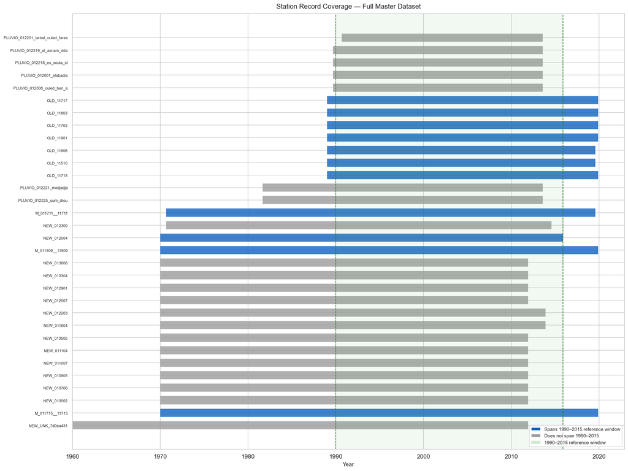

```
Saved: 00_station_coverage_timeline.png
```

```python
# ── Station timeline figure ────────────────────────────────────────────────────
sids = coverage.sort_values("start_date")[STATION_COL].tolist()
N    = len(sids)

fig, ax = plt.subplots(figsize=(17, max(7, N * 0.40)))

for i, sid in enumerate(sids):
    row   = coverage[coverage[STATION_COL] == sid].iloc[0]
    color = "#1565C0" if row["spans_1990_2015"] else "#9E9E9E"
    ax.barh(i, left=row["start_date"],
            width=(row["end_date"] - row["start_date"]).days,
            height=0.65, color=color, alpha=0.82, linewidth=0)

ax.axvspan(REF_START, REF_END, alpha=0.07, color="#4CAF50")
ax.axvline(REF_START, color="#2E7D32", linestyle="--", linewidth=1.1)
ax.axvline(REF_END,   color="#2E7D32", linestyle="--", linewidth=1.1)
ax.set_yticks(range(N))
ax.set_yticklabels(sids, fontsize=7.5)
ax.set_xlabel("Year", fontsize=11)
ax.set_title("Station Record Coverage — Full Master Dataset", fontsize=13, pad=10)
ax.legend(handles=[
    mpatches.Patch(facecolor="#1565C0", label="Spans 1990–2015 reference window"),
    mpatches.Patch(facecolor="#9E9E9E", label="Does not span 1990–2015"),
    mpatches.Patch(facecolor="#4CAF50", alpha=0.25, label="1990–2015 reference window"),
], loc="lower right", fontsize=9)
plt.tight_layout()
fig.savefig(OUT_DIR / "00_station_coverage_timeline.png", dpi=150)
plt.show()
print("Saved: 00_station_coverage_timeline.png")
```

## Section 8 — Frequency and Regularity Check

SPI rolling-window accumulations assume strictly monthly, uniformly spaced records. Any deviation — a bimonthly gap, a sub-monthly record, or a duplicate-month entry — shifts the accumulation window by the size of the irregularity, producing silently incorrect SPI values without raising any computation error. We verify that all consecutive records within each station are separated by exactly 28–31 days (one calendar month).

**Why monthly regularity is essential for SPI**: the SPI-$k$ value for month $t$ is defined as the standardised value of the $k$-month rolling precipitation sum ending at $t$. If the time series contains a two-month gap at any point within the accumulation window, the rolling sum incorrectly aggregates only $k-1$ months of precipitation and assigns it the SPI scale of $k$ months, producing a bias that is invisible from the SPI value alone.

```python
irregular_events = []

for sid, grp in precip.groupby(STATION_COL):
    dates  = grp[DATE_COL].sort_values().reset_index(drop=True)
    deltas = dates.diff().dropna()
    bad    = deltas[(deltas.dt.days < 28) | (deltas.dt.days > 31)]
    for idx, delta in bad.items():
        irregular_events.append({
            STATION_COL:         sid,
            "gap_from":          dates.iloc[idx - 1],
            "gap_to":            dates.iloc[idx],
            "gap_days":          delta.days,
            "gap_months_approx": round(delta.days / 30.44, 1),
        })

irr_df = pd.DataFrame(irregular_events)
print(f"Irregular time-step events detected: {len(irr_df)}")

if len(irr_df) > 0:
    print("\nDetail (sorted by gap size, descending):")
    display(irr_df.sort_values("gap_days", ascending=False))
    print("\nNote: these correspond to structural gaps — months entirely absent from")
    print("all source archives. They will be made explicit in Section 9.")
else:
    print("  ✓ All consecutive records are separated by exactly one calendar month.")
```

```
Irregular time-step events detected: 4

Detail (sorted by gap size, descending):
```

|  | master_station_id | gap_from | gap_to | gap_days | gap_months_approx |
| --- | --- | --- | --- | --- | --- |
| 3 | PLUVIO_012221_medjadja | 1985-08-01 | 1990-09-01 | 1857 | 61.0000 |
| 0 | M_011711__11711 | 1977-08-01 | 1978-09-01 | 396 | 13.0000 |
| 1 | NEW_010905 | 2002-12-01 | 2004-01-01 | 396 | 13.0000 |
| 2 | NEW_011007 | 2000-12-01 | 2002-01-01 | 396 | 13.0000 |

```
Note: these correspond to structural gaps — months entirely absent from
all source archives. They will be made explicit in Section 9.
```

## Section 9 — Full Monthly Grid Construction

### Why the raw dataset understates missingness

The raw precipitation dataframe contains only the rows that were physically present in the source archives. A month entirely absent from all three sub-archives leaves no trace in the file — there is no NaN row, there is simply no row. Any missing fraction computed directly from the raw data is therefore optimistic and misleading: a station that reported only 70% of months appears to have zero missing values.

### Construction procedure

For each station $s$ with earliest observation $t_s^{\min}$ and latest observation $t_s^{\max}$, we construct the complete monthly sequence:

$$\mathcal{T}_s = \bigl\{t_s^{\min},\; t_s^{\min}+1\text{M},\; \ldots,\; t_s^{\max}\bigr\}$$

using `freq="MS"` (Month Start, anchored to the first day of each month), then perform a **left join** of the observations onto this grid. Months absent from the archives become explicit `NaN` rows in the output. This operation adds no values and modifies no values — it only makes implicit gaps visible.

```python
frames = []
for sid, grp in precip.groupby(STATION_COL):
    grid = pd.DataFrame({
        STATION_COL: sid,
        DATE_COL:    pd.date_range(grp[DATE_COL].min(), grp[DATE_COL].max(), freq="MS"),
    })
    merged = grid.merge(
        grp[[STATION_COL, DATE_COL, PRECIP_COL, "value_source", "source_dataset"]],
        on=[STATION_COL, DATE_COL], how="left"
    )
    frames.append(merged)

precip_grid = pd.concat(frames, ignore_index=True)
n_added = len(precip_grid) - len(precip)

print(f"Rows before grid construction: {len(precip):,}")
print(f"Rows after  grid construction: {len(precip_grid):,}")
print(f"Rows added (implicit gaps now explicit): {n_added:,}")
print()
print("These additional rows correspond to months that were entirely absent from")
print("all source archives. They now appear as explicit NaN entries.")

precip_grid.to_csv(OUT_DIR / "00_precipitation_full_grid.csv", index=False, date_format="%Y-%m-%d")
print("\nSaved: 00_precipitation_full_grid.csv")
```

```
Rows before grid construction: 14,284
Rows after  grid construction: 14,380
Rows added (implicit gaps now explicit): 96

These additional rows correspond to months that were entirely absent from
all source archives. They now appear as explicit NaN entries.

Saved: 00_precipitation_full_grid.csv
```

## Section 10 — Missingness After Full-Grid Construction

With implicit gaps now explicit, we recompute the true missingness statistics. This is the **comprehensive missing-data characterisation** of the dataset. Three quantities are computed per station:

1. **Global missing fraction** — proportion of all grid months with no observed value.
2. **Maximum contiguous gap** — length of the longest uninterrupted run of missing months. Gaps exceeding 3 consecutive months cannot be filled by linear interpolation and constitute grounds for station exclusion in the next notebook.
3. **Completeness within the 1990–2015 reference window** — fraction of the 312 reference months that have an observed value. This is the operative metric for Eligibility Condition C1.

```python
# Global missing fraction per station
miss_grid = (
    precip_grid
    .assign(is_missing=precip_grid[PRECIP_COL].isna())
    .groupby(STATION_COL)
    .agg(n_grid=("is_missing", "size"), n_missing=("is_missing", "sum"))
    .assign(missing_pct=lambda d: 100 * d["n_missing"] / d["n_grid"])
    .reset_index()
)

# Maximum contiguous gap
def max_contiguous_gap(series):
    """Length of the longest run of NaN values in the series."""
    max_g = cur_g = 0
    for v in series:
        if pd.isna(v):
            cur_g += 1
            max_g  = max(max_g, cur_g)
        else:
            cur_g = 0
    return max_g

mcg = (
    precip_grid.groupby(STATION_COL)[PRECIP_COL]
    .apply(max_contiguous_gap)
    .rename("max_contiguous_gap")
    .reset_index()
)

# Completeness in reference window
REF_MONTHS = 312
ref_sub = precip_grid[
    (precip_grid[DATE_COL] >= REF_START) & (precip_grid[DATE_COL] <= REF_END)
]
comp_ref = (
    ref_sub.groupby(STATION_COL)[PRECIP_COL]
    .apply(lambda x: x.notna().sum())
    .rename("n_obs_in_ref")
    .reset_index()
)
comp_ref["completeness_1990_2015"] = comp_ref["n_obs_in_ref"] / REF_MONTHS

# Assemble
miss_summary = (
    miss_grid
    .merge(mcg,      on=STATION_COL)
    .merge(comp_ref, on=STATION_COL, how="left")
    .sort_values("missing_pct", ascending=False)
)
miss_summary["eligible_C1"] = miss_summary["completeness_1990_2015"] >= 0.90
miss_summary["eligible_C2"] = miss_summary["max_contiguous_gap"]    <= 3

print("True missingness per station (after full-grid construction):")
display(
    miss_summary.style
    .bar(subset=["missing_pct"],          color="#ef5350")
    .bar(subset=["completeness_1990_2015"],color=["#ef5350", "#66bb6a"], vmin=0, vmax=1)
    .format({"missing_pct": "{:.1f}%", "completeness_1990_2015": "{:.3f}"})
)

miss_summary.to_csv(OUT_DIR / "missing_by_station.csv", index=False)
print("Saved: missing_by_station.csv")
```

```
True missingness per station (after full-grid construction):
```

|  | master_station_id | n_grid | n_missing | missing_pct | max_contiguous_gap | n_obs_in_ref | completeness_1990_2015 | eligible_C1 | eligible_C2 |
| --- | --- | --- | --- | --- | --- | --- | --- | --- | --- |
| 0 | M_011509__11509 | 600 | 219 | 36.5% | 218 | 312 | 1.000 | True | False |
| 30 | PLUVIO_012225_oum_drou | 384 | 130 | 33.9% | 120 | 254 | 0.814 | False | False |
| 29 | PLUVIO_012221_medjadja | 384 | 121 | 31.5% | 108 | 263 | 0.843 | False | False |
| 23 | OLD_11803 | 372 | 21 | 5.6% | 5 | 296 | 0.949 | True | False |
| 27 | PLUVIO_012218_es_soula_st | 288 | 16 | 5.6% | 7 | 268 | 0.859 | False | False |
| 22 | OLD_11718 | 372 | 20 | 5.4% | 5 | 303 | 0.971 | True | False |
| 26 | PLUVIO_012201_larbat_ouled_fares | 276 | 13 | 4.7% | 9 | 263 | 0.843 | False | False |
| 20 | OLD_11702 | 372 | 17 | 4.6% | 5 | 302 | 0.968 | True | False |
| 1 | M_011711__11711 | 588 | 18 | 3.1% | 12 | 309 | 0.990 | True | False |
| 19 | OLD_11606 | 368 | 11 | 3.0% | 5 | 308 | 0.987 | True | False |
| 24 | OLD_11901 | 372 | 11 | 3.0% | 2 | 308 | 0.987 | True | True |
| 5 | NEW_010905 | 504 | 13 | 2.6% | 12 | 251 | 0.804 | False | False |
| 6 | NEW_011007 | 504 | 12 | 2.4% | 12 | 252 | 0.808 | False | False |
| 7 | NEW_011104 | 504 | 11 | 2.2% | 4 | 253 | 0.811 | False | False |
| 18 | OLD_11510 | 368 | 7 | 1.9% | 2 | 308 | 0.987 | True | True |
| 28 | PLUVIO_012219_el_asnam_dda | 288 | 4 | 1.4% | 2 | 280 | 0.897 | False | True |
| 25 | PLUVIO_012001_elabadia | 288 | 3 | 1.0% | 1 | 281 | 0.901 | True | True |
| 2 | M_011715__11715 | 600 | 5 | 0.8% | 1 | 312 | 1.000 | True | True |
| 3 | NEW_010502 | 504 | 3 | 0.6% | 1 | 261 | 0.837 | False | True |
| 21 | OLD_11717 | 372 | 2 | 0.5% | 1 | 312 | 1.000 | True | True |
| 16 | NEW_013606 | 504 | 2 | 0.4% | 1 | 262 | 0.840 | False | True |
| 4 | NEW_010706 | 504 | 2 | 0.4% | 1 | 262 | 0.840 | False | True |
| 11 | NEW_012309 | 528 | 2 | 0.4% | 1 | 294 | 0.942 | True | True |
| 9 | NEW_012004 | 552 | 2 | 0.4% | 1 | 310 | 0.994 | True | True |
| 31 | PLUVIO_012308_ouled_ben_a | 288 | 1 | 0.3% | 1 | 283 | 0.907 | True | True |
| 14 | NEW_013304 | 504 | 1 | 0.2% | 1 | 264 | 0.846 | False | True |
| 10 | NEW_012203 | 528 | 1 | 0.2% | 1 | 287 | 0.920 | True | True |
| 8 | NEW_011604 | 528 | 1 | 0.2% | 1 | 287 | 0.920 | True | True |
| 17 | NEW_UNK_7d0ea431 | 624 | 0 | 0.0% | 0 | 264 | 0.846 | False | True |
| 15 | NEW_013505 | 504 | 0 | 0.0% | 0 | 264 | 0.846 | False | True |
| 13 | NEW_012901 | 504 | 0 | 0.0% | 0 | 264 | 0.846 | False | True |
| 12 | NEW_012507 | 504 | 0 | 0.0% | 0 | 264 | 0.846 | False | True |

```
Saved: missing_by_station.csv
```

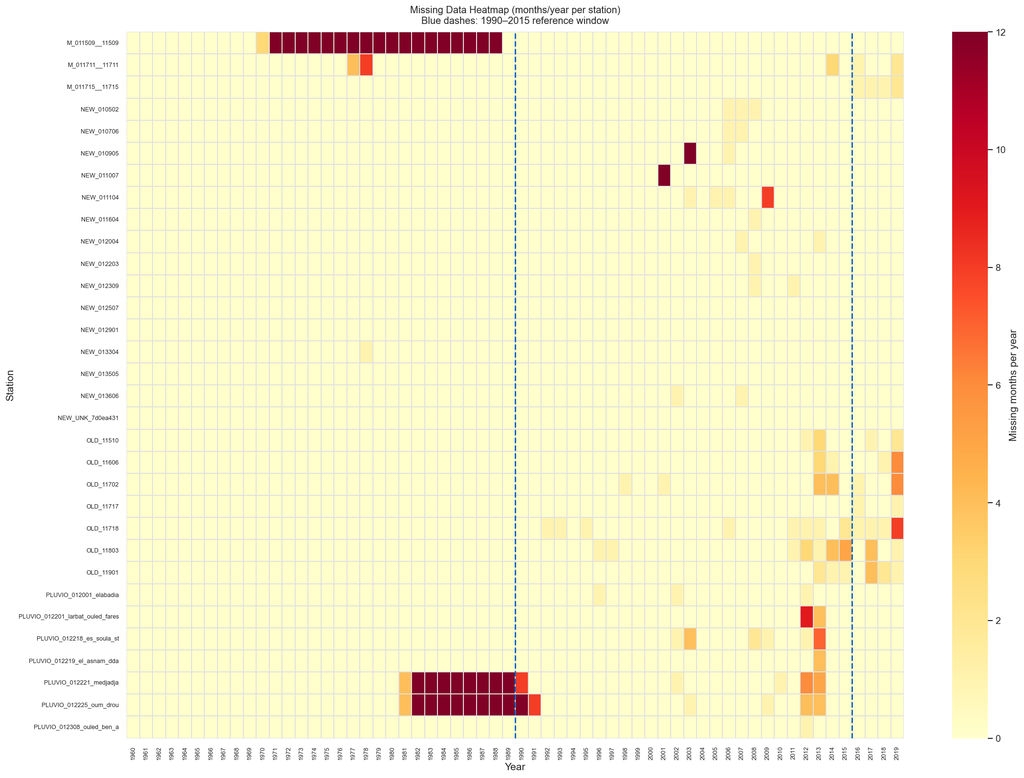

```
Saved: 00_missing_heatmap.png
```

```python
# ── Missing-data heatmap ───────────────────────────────────────────────────────
pg = precip_grid.copy()
pg["year"] = pg[DATE_COL].dt.year
heat = (
    pg.assign(is_missing=pg[PRECIP_COL].isna())
    .groupby([STATION_COL, "year"])["is_missing"]
    .sum()
    .unstack(fill_value=0)
)

fig, ax = plt.subplots(figsize=(19, max(7, len(heat) * 0.42)))
sns.heatmap(
    heat, ax=ax, cmap="YlOrRd",
    linewidths=0.2, linecolor="#e0e0e0",
    cbar_kws={"label": "Missing months per year"},
    vmin=0, vmax=12
)
# Mark reference window
if 1990 in heat.columns:
    ax.axvline(heat.columns.get_loc(1990),   color="#1565C0", linewidth=1.8, linestyle="--")
    ax.axvline(heat.columns.get_loc(2015)+1, color="#1565C0", linewidth=1.8, linestyle="--")
ax.set_title("Missing Data Heatmap (months/year per station)\nBlue dashes: 1990–2015 reference window",
             fontsize=12, pad=10)
ax.set_xlabel("Year")
ax.set_ylabel("Station")
ax.tick_params(axis="x", rotation=90, labelsize=7.5)
ax.tick_params(axis="y", labelsize=7.5)
plt.tight_layout()
fig.savefig(OUT_DIR / "00_missing_heatmap.png", dpi=150)
plt.show()
print("Saved: 00_missing_heatmap.png")
```

## Section 11 — Descriptive Climatology and Sanity Checks

Before any index is constructed, two classes of anomaly must be explicitly identified:

1. **Negative precipitation values**: physically impossible and definitionally incompatible with the Gamma distribution, whose support is strictly $(0, +\infty)$. A negative value passed to the Gamma fitter will either cause a numerical failure or produce a physically meaningless parameter estimate.
2. **Extreme positive outliers**: values exceeding ~250 mm/month for a semi-arid Algerian basin are climatologically implausible and likely represent transcription errors in the digitisation process. They inflate the right tail of the empirical distribution and bias the Gamma shape parameter upward.

Both anomaly types are reported here. They are not removed in this notebook.

```python
EXTREME_THRESH = 250.0  # mm/month — physically generous upper bound

# Negative values
neg = precip[precip[PRECIP_COL] < 0]
print(f"Negative precipitation records: {len(neg)}")
if len(neg) > 0:
    display(neg[[STATION_COL, DATE_COL, PRECIP_COL, "value_source", "source_dataset"]])
    print("  ⚠ These must be removed or set to NaN before Gamma distribution fitting.")

# Extreme positive values
ext = precip[precip[PRECIP_COL] > EXTREME_THRESH]
print(f"\nRecords > {EXTREME_THRESH} mm/month: {len(ext)}")
if len(ext) > 0:
    display(ext[[STATION_COL, DATE_COL, PRECIP_COL, "source_dataset"]].sort_values(PRECIP_COL, ascending=False))

# Global summary statistics
print("\nGlobal precipitation statistics (mm/month, all stations and years):")
print(precip[PRECIP_COL].describe(percentiles=[.01,.05,.25,.5,.75,.95,.99]).round(2).to_string())
```

```
Negative precipitation records: 22
```

|  | master_station_id | date | precip_mm | value_source | source_dataset |
| --- | --- | --- | --- | --- | --- |
| 12158 | PLUVIO_012001_elabadia | 1990-07-01 | -999.0000 | observed_pluvio_fill_master_gap | pluvio_chlef_fill |
| 12170 | PLUVIO_012001_elabadia | 1991-07-01 | -999.0000 | observed_pluvio_fill_master_gap | pluvio_chlef_fill |
| 12171 | PLUVIO_012001_elabadia | 1991-08-01 | -999.0000 | observed_pluvio_fill_master_gap | pluvio_chlef_fill |
| 12185 | PLUVIO_012001_elabadia | 1992-10-01 | -999.0000 | observed_pluvio_fill_master_gap | pluvio_chlef_fill |
| 12190 | PLUVIO_012001_elabadia | 1993-03-01 | -999.0000 | observed_pluvio_fill_master_gap | pluvio_chlef_fill |
| 12196 | PLUVIO_012001_elabadia | 1993-09-01 | -999.0000 | observed_pluvio_fill_master_gap | pluvio_chlef_fill |
| 12197 | PLUVIO_012001_elabadia | 1993-10-01 | -999.0000 | observed_pluvio_fill_master_gap | pluvio_chlef_fill |
| 12198 | PLUVIO_012001_elabadia | 1993-11-01 | -999.0000 | observed_pluvio_fill_master_gap | pluvio_chlef_fill |
| 12447 | PLUVIO_012201_larbat_ouled_fares | 1991-08-01 | -999.0000 | observed_pluvio_fill_master_gap | pluvio_chlef_fill |
| 13429 | PLUVIO_012221_medjadja | 1998-06-01 | -999.0000 | observed_pluvio_fill_master_gap | pluvio_chlef_fill |
| 13526 | PLUVIO_012221_medjadja | 2006-07-01 | -999.0000 | observed_pluvio_fill_master_gap | pluvio_chlef_fill |
| 13732 | PLUVIO_012225_oum_drou | 1991-09-01 | -999.0000 | observed_pluvio_fill_master_gap | pluvio_chlef_fill |
| 13733 | PLUVIO_012225_oum_drou | 1991-10-01 | -999.0000 | observed_pluvio_fill_master_gap | pluvio_chlef_fill |
| 13734 | PLUVIO_012225_oum_drou | 1991-11-01 | -999.0000 | observed_pluvio_fill_master_gap | pluvio_chlef_fill |
| 13739 | PLUVIO_012225_oum_drou | 1992-04-01 | -999.0000 | observed_pluvio_fill_master_gap | pluvio_chlef_fill |
| 13740 | PLUVIO_012225_oum_drou | 1992-05-01 | -999.0000 | observed_pluvio_fill_master_gap | pluvio_chlef_fill |
| 13742 | PLUVIO_012225_oum_drou | 1992-07-01 | -999.0000 | observed_pluvio_fill_master_gap | pluvio_chlef_fill |
| 13743 | PLUVIO_012225_oum_drou | 1992-08-01 | -999.0000 | observed_pluvio_fill_master_gap | pluvio_chlef_fill |
| 13910 | PLUVIO_012225_oum_drou | 2006-07-01 | -999.0000 | observed_pluvio_fill_master_gap | pluvio_chlef_fill |
| 14052 | PLUVIO_012308_ouled_ben_a | 1994-05-01 | -999.0000 | observed_pluvio_fill_master_gap | pluvio_chlef_fill |
| 14138 | PLUVIO_012308_ouled_ben_a | 2001-07-01 | -999.0000 | observed_pluvio_fill_master_gap | pluvio_chlef_fill |
| 14198 | PLUVIO_012308_ouled_ben_a | 2006-07-01 | -999.0000 | observed_pluvio_fill_master_gap | pluvio_chlef_fill |

```
  ⚠ These must be removed or set to NaN before Gamma distribution fitting.

Records > 250.0 mm/month: 9
```

|  | master_station_id | date | precip_mm | source_dataset |
| --- | --- | --- | --- | --- |
| 552 | M_011509__11509 | 2016-01-01 | 346.9000 | merged_pair |
| 434 | M_011509__11509 | 2006-03-01 | 311.6000 | merged_pair |
| 11464 | OLD_11803 | 1994-01-01 | 287.2000 | old |
| 11428 | OLD_11803 | 1991-01-01 | 282.4000 | old |
| 2171 | NEW_010502 | 2002-12-01 | 267.5000 | new |
| 529 | M_011509__11509 | 2014-02-01 | 262.2000 | merged_pair |
| 9086 | NEW_UNK_7d0ea431 | 1973-03-01 | 257.4000 | new |
| 9009 | NEW_UNK_7d0ea431 | 1966-10-01 | 254.8000 | new |
| 542 | M_011509__11509 | 2015-03-01 | 253.7000 | merged_pair |

```
Global precipitation statistics (mm/month, all stations and years):
count   13711.0000
mean       27.6200
std        52.6200
min      -999.0000
1%          0.0000
5%          0.0000
25%         3.1000
50%        19.1000
75%        44.5000
95%        92.9000
99%       136.0800
max       346.9000
```

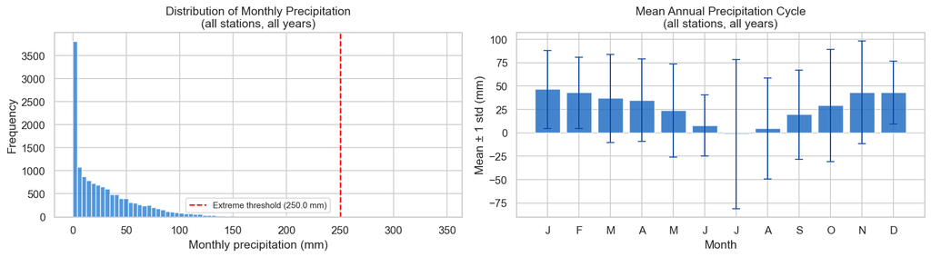

```
Saved: 00_precip_distribution.png
```

```python
# ── Precipitation distribution ────────────────────────────────────────────────
fig, axes = plt.subplots(1, 2, figsize=(14, 4))

valid = precip[precip[PRECIP_COL] >= 0][PRECIP_COL].dropna()
axes[0].hist(valid, bins=80, color="#1976D2", alpha=0.75, edgecolor="white")
axes[0].axvline(EXTREME_THRESH, color="red", linestyle="--",
                label=f"Extreme threshold ({EXTREME_THRESH} mm)")
axes[0].set_xlabel("Monthly precipitation (mm)")
axes[0].set_ylabel("Frequency")
axes[0].set_title("Distribution of Monthly Precipitation\n(all stations, all years)")
axes[0].legend(fontsize=9)

pg2 = precip.copy()
pg2["month"] = pg2[DATE_COL].dt.month
mc = pg2.groupby("month")[PRECIP_COL].agg(["mean","std"]).reset_index()
axes[1].bar(mc["month"], mc["mean"], color="#1565C0", alpha=0.80)
axes[1].errorbar(mc["month"], mc["mean"], yerr=mc["std"],
                 fmt="none", color="#0D47A1", capsize=4, linewidth=1.2)
axes[1].set_xticks(range(1,13))
axes[1].set_xticklabels(list("JFMAMJJASOND"))
axes[1].set_xlabel("Month")
axes[1].set_ylabel("Mean ± 1 std (mm)")
axes[1].set_title("Mean Annual Precipitation Cycle\n(all stations, all years)")

plt.tight_layout()
fig.savefig(OUT_DIR / "00_precip_distribution.png", dpi=150)
plt.show()
print("Saved: 00_precip_distribution.png")
```

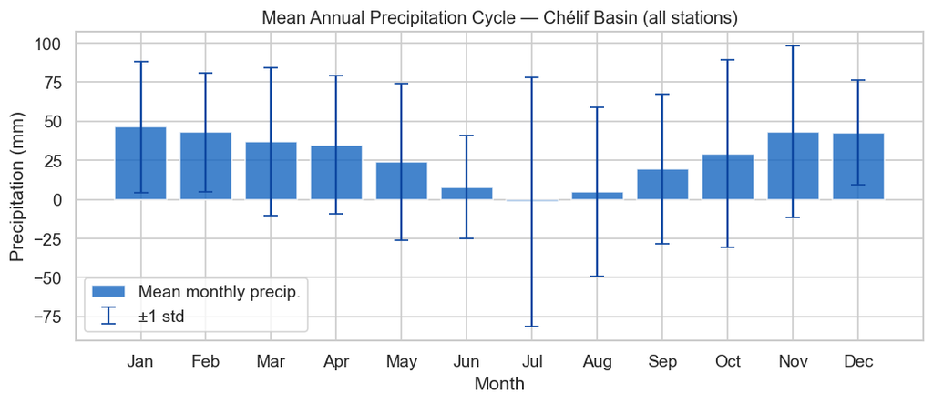

```
Saved: 00_mean_annual_cycle.png
```

```python
# ── Mean annual cycle figure (standalone) ─────────────────────────────────────
fig, ax = plt.subplots(figsize=(9, 4))
ax.bar(mc["month"], mc["mean"], color="#1565C0", alpha=0.80, label="Mean monthly precip.")
ax.errorbar(mc["month"], mc["mean"], yerr=mc["std"],
            fmt="none", color="#0D47A1", capsize=5, linewidth=1.4, label="±1 std")
ax.set_xticks(range(1,13))
ax.set_xticklabels(["Jan","Feb","Mar","Apr","May","Jun",
                     "Jul","Aug","Sep","Oct","Nov","Dec"])
ax.set_xlabel("Month")
ax.set_ylabel("Precipitation (mm)")
ax.set_title("Mean Annual Precipitation Cycle — Chélif Basin (all stations)", fontsize=12)
ax.legend()
plt.tight_layout()
fig.savefig(OUT_DIR / "00_mean_annual_cycle.png", dpi=150)
plt.show()
print("Saved: 00_mean_annual_cycle.png")
```

## Section A — Study Period Selection: Criteria Framework

The selection of an analysis period is not a cosmetic choice — it determines which stations are eligible, how many observations are available per calendar month for Gamma distribution fitting, and whether the resulting SPI series can be validated against the two historically documented drought episodes in the Chélif basin (1999–2002 and 2006–2011).

All five criteria below are stated **a priori**, before any period is tested, to ensure the selection process is objective and reproducible.

### Criterion 1 — Minimum temporal length (WMO requirement)

The WMO (2012) recommends a minimum of 30 years for climatological reference periods. For SPI applications in data-sparse basins, shorter periods (≥ 25 years) are accepted provided the fitting sample per calendar month is large enough for stable Gamma parameter estimation. With 12 calendar months and $N$ years of record, the effective per-month fitting sample is $N$:

$$N_{\text{months}} \geq 300 \quad (25 \text{ years}) \qquad \Leftrightarrow \qquad n_{\text{per-month}} \geq 25$$

This is the binding constraint from Stagge et al. (2015), and it sets a hard lower bound on acceptable period length.

### Criterion 2 — Number of usable stations

Not all available stations are equally reliable. A station is considered **usable** if its pre-fill completeness over the candidate window satisfies:

$$c_{\text{before}}(i) = \frac{n_{\text{obs}}(i)}{N} \geq 0.90$$

This threshold ensures that at most 10 % of the station's monthly record would require imputation, keeping the interpolated fraction well below the level at which Gamma distribution parameter estimates become unreliable.

> **Metric added in this notebook:** `n_usable_stations` = number of stations satisfying $c_{\text{before}} \geq 0.90$ within the candidate window. This is the **primary selection metric** — we seek the period that maximises it.

A second, stricter condition (Criterion 4) requires that no unfillable contiguous gap exists, which further filters the usable set to *eligible* stations that can be carried through the full pipeline.

### Criterion 3 — Mean completeness across usable stations

Beyond binary usability, the **mean** $\bar{c}_{\text{before}}$ across all usable stations must remain high. A period with many usable stations but low mean completeness implies that most of those stations are borderline (≈ 90 %) and will contribute heavily imputed series to the SPI panel — degrading the reliability of distributional fits.

$$\bar{c}_{\text{before}} \geq 0.90 \quad \text{(averaged over usable stations)}$$

### Criterion 4 — Gap continuity constraint

Linear interpolation is valid only for contiguous gaps of at most **3 consecutive missing months** (thesis equation 1.7). Periods that expose longer gaps at a station cannot be resolved by interpolation; that station is disqualified from the analytical panel, reducing the effective network.

$$g_{\max}(i) \leq 3 \text{ months}$$

### Criterion 5 — Hydroclimatological representativeness

The selected period must span both major drought episodes identified in the Chélif basin literature: **1999–2002** and **2006–2011**. These episodes serve as primary validation targets for the SPI and scPDSI indices constructed in subsequent chapters. A period that truncates before December 2011 cannot be used for that validation.

### Hierarchical decision rule

When multiple candidate periods satisfy all five criteria, the **final selection follows this priority order**:

1. **Maximise `n_usable_stations`** — more reliable stations produce a spatially richer and statistically more robust regional SPI series.
2. **Maximise mean completeness** — higher $\bar{c}_{\text{before}}$ reduces dependence on imputed values.
3. **Satisfy WMO minimum length (≥ 25 years)** — ensures adequate per-month fitting sample for the Gamma distribution.
4. **Minimise missing data concentration and fragmentation** — avoids periods where missing values cluster in specific years or stations, which would bias the seasonal distribution fits.

This rule is applied explicitly in Section E after the comparison table is computed.

### Connection to SPI computation

The SPI Gamma distribution is **fitted separately for each of the 12 calendar months**. The reason is that precipitation in semi-arid Algeria is highly seasonal: January may average 60–80 mm while July averages near zero. A single annual fit would pool these incommensurable distributions and produce meaningless standardised values.

## Section B — Visual Evidence: Station Coverage Over Time

Before constructing the formal comparison table, we visualise two time-varying quantities that together motivate the 1990–2015 selection:

1. **Active station count per year**: how many stations reported data in each year.
2. **K eligible stations as a function of start year** (end fixed at 2015): how the number of jointly eligible stations changes as the window is extended backward.

These plots provide the *data-driven rationale* for why the selection is made at 1990 rather than 1985 or 1980.

```python
# ─── B.1  Annual active station count ────────────────────────────────────────
# A station-year is 'active' if it has at least 6 valid observations that year.
precip_grid["year"] = precip_grid[DATE_COL].dt.year

annual_obs = (
    precip_grid
    .groupby(["year", STATION_COL])[PRECIP_COL]
    .apply(lambda x: x.notna().sum())
    .reset_index()
)
annual_obs.columns = ["year", STATION_COL, "n_obs_yr"]

active_per_year = (
    annual_obs[annual_obs["n_obs_yr"] >= 6]
    .groupby("year")
    .size()
    .reset_index(name="n_active_stations")
)

print("Annual active station counts (≥6 observations):")
print(active_per_year.set_index("year").T.to_string())
```

```
Annual active station counts (≥6 observations):
year               1960  1961  1962  1963  1964  1965  1966  1967  1968  1969  1970  1971  1972  1973  1974  1975  1976  1977  1978  1979  1980  1981  1982  1983  1984  1985  1986  1987  1988  1989  1990  1991  1992  1993  1994  1995  1996  1997  1998  1999  2000  2001  2002  2003  2004  2005  2006 …
n_active_stations     1     1     1     1     1     1     1     1     1     1    16    17    17    17    17    17    17    17    16    17    17    17    17    17    17    17    17    17    17    25    29    31    32    32    32    32    32    32    32    32    32    31    32    31    32    32    32 …
```

```python
# ─── B.2  K eligible stations as function of start year (end = 2015-12) ──────
# This reproduces Figure 1.3 from the thesis.

def max_contiguous_gap(series: np.ndarray) -> int:
    """Length of the longest run of NaN values."""
    max_gap = cur = 0
    for v in series:
        if np.isnan(float(v)) if not pd.isna(v) else True:
            if pd.isna(v):
                cur += 1; max_gap = max(max_gap, cur)
            else:
                cur = 0
        else:
            cur = 0
    return max_gap

def max_contiguous_gap_series(series: pd.Series) -> int:
    max_gap = cur = 0
    for v in series:
        if pd.isna(v): cur += 1; max_gap = max(max_gap, cur)
        else: cur = 0
    return max_gap

TARGET_END_2015 = pd.Timestamp("2015-12-01")
K_by_start = []

for start_year in range(1975, 2005):
    ts = pd.Timestamp(f"{start_year}-01-01")
    n_months = (TARGET_END_2015.year - ts.year) * 12 + (TARGET_END_2015.month - ts.month) + 1
    if n_months < 12:
        continue
    win = precip_grid[(precip_grid[DATE_COL] >= ts) & (precip_grid[DATE_COL] <= TARGET_END_2015)]
    stats = win.groupby(STATION_COL).apply(
        lambda x: pd.Series({
            "n_obs": x[PRECIP_COL].notna().sum(),
            "max_gap": max_contiguous_gap_series(x[PRECIP_COL]),
        })
    ).reset_index()
    stats["c_before"] = stats["n_obs"] / n_months
    K = int(((stats["c_before"] >= 0.90) & (stats["max_gap"] <= 3)).sum())
    K_by_start.append({"start_year": start_year, "n_months": n_months, "length_years": round(n_months / 12, 1), "K": K})

K_df = pd.DataFrame(K_by_start)
print("K eligible stations by start year (end = 2015-12):")
print(K_df.set_index("start_year")[["length_years", "K"]].to_string())
```

```
K eligible stations by start year (end = 2015-12):
            length_years   K
start_year
1975             41.0000  10
1976             40.0000   9
1977             39.0000   5
1978             38.0000   5
1979             37.0000   6
1980             36.0000   6
1981             35.0000   6
1982             34.0000   6
1983             33.0000   6
1984             32.0000   6
1985             31.0000   6
1986             30.0000   7
```

[output cut: 18 more lines]

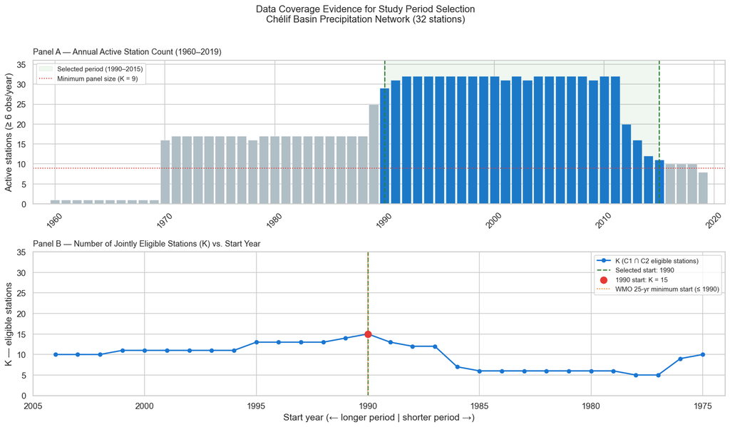

```
Saved: 00_period_selection_coverage.png
```

```python
# ─── B.3  Figure: Station coverage and K eligible stations ───────────────────
fig, axes = plt.subplots(2, 1, figsize=(14, 8), sharex=False)

# ── Panel 1: active stations per year ──────────────────────────────────────
ax1 = axes[0]
bar_colors = [
    "#1976D2" if (y >= 1990 and y <= 2015) else "#B0BEC5"
    for y in active_per_year["year"]
]
ax1.bar(active_per_year["year"], active_per_year["n_active_stations"],
        color=bar_colors, width=0.85, edgecolor="white", linewidth=0.3)
ax1.axvspan(1990, 2015, alpha=0.08, color="#43A047", label="Selected period (1990–2015)")
ax1.axvline(1990, color="#2E7D32", linestyle="--", linewidth=1.5)
ax1.axvline(2015, color="#2E7D32", linestyle="--", linewidth=1.5)
ax1.axhline(9, color="#E53935", linestyle=":", linewidth=1.2, label="Minimum panel size (K = 9)")
ax1.set_ylabel("Active stations (≥ 6 obs/year)")
ax1.set_title("Panel A — Annual Active Station Count (1960–2019)", fontsize=11, loc="left", pad=8)
ax1.legend(fontsize=9, loc="upper left")
ax1.set_xlim(1958, 2021)
ax1.set_ylim(0, 36)
ax1.tick_params(axis="x", rotation=45)

# ── Panel 2: K eligible stations by start year ─────────────────────────────
ax2 = axes[1]
ax2.plot(K_df["start_year"], K_df["K"], marker="o", markersize=5,
         color="#1976D2", linewidth=1.8, label="K (C1 ∩ C2 eligible stations)")
ax2.axvline(1990, color="#2E7D32", linestyle="--", linewidth=1.5, label="Selected start: 1990")
ax2.scatter([1990], [K_df.loc[K_df["start_year"] == 1990, "K"].values[0]],
            color="#E53935", zorder=5, s=80, label=f"1990 start: K = {K_df.loc[K_df['start_year']==1990,'K'].values[0]}")

# Mark WMO 25-year minimum
wmo_year = 2015 - 25  # = 1990
ax2.axvline(wmo_year, color="#FF6F00", linestyle=":", linewidth=1.2,
            label=f"WMO 25-yr minimum start (≤ {wmo_year})")

ax2.set_xlabel("Start year (period end fixed at 2015-12)")
ax2.set_ylabel("K — eligible stations")
ax2.set_title("Panel B — Number of Jointly Eligible Stations (K) vs. Start Year", fontsize=11, loc="left", pad=8)
ax2.legend(fontsize=9)
ax2.set_ylim(0, 35)
ax2.set_xlim(1974, 2005)
ax2.invert_xaxis()  # left = longer period, right = shorter
ax2.set_xlabel("Start year (← longer period | shorter period →)")

plt.suptitle(
    "Data Coverage Evidence for Study Period Selection\n"
    "Chélif Basin Precipitation Network (32 stations)",
    fontsize=13, y=1.01
)
plt.tight_layout()
fig.savefig(OUT_DIR / "00_period_selection_coverage.png", dpi=150, bbox_inches="tight")
plt.show()
print("Saved: 00_period_selection_coverage.png")
```

## Section C — Candidate Period Comparison Table

Five candidate periods are evaluated systematically. They were identified from the coverage plots in Section B and from the prior literature on data availability in the Chélif basin. They span a range of start years (1980–1991) and end years (2010–2019), deliberately chosen to bracket the realistic trade-off space between record length and data quality.

| Metric | Symbol | Definition |
| --- | --- | --- |
| Record length | $N$ | Total months in the window |
| Obs. per month | $n/\text{month}$ | $N \div 12$ — effective Gamma fitting sample |
| WMO ≥ 25 yr | — | $n/\text{month} \geq 25$ (Stagge et al., 2015) |
| **Usable stations** | $n_{\text{usable}}$ | Stations with $c_{\text{before}} \geq 0.90$ |
| **% usable** | $p_{\text{usable}}$ | $n_{\text{usable}} / 32$ |
| Mean completeness | $\bar{c}_{\text{before}}$ | Mean over usable stations |
| Missing % | — | Global NaN fraction across all station-months |
| **K eligible** | $K$ | Stations satisfying C1 ($c \geq 0.90$) **and** C2 ($g_{\max} \leq 3$) |

> **Note on `n_usable_stations` vs `K eligible`:** `n_usable_stations` counts stations passing the completeness threshold only (C1). `K eligible` is the stricter count that additionally requires gap continuity (C2). Both metrics are necessary: `n_usable_stations` captures the breadth of the usable network, while `K eligible` identifies the subset that can actually be carried through the full pipeline to produce gap-free SPI series.

> The **comparison table is sorted by `n_usable_stations` (descending), then by `Mean c_before` (descending)**, following the hierarchical decision rule stated in Section A.

```python
# ─── C.1  Define candidate periods ────────────────────────────────────────────
# These periods were identified from the coverage plots and prior literature.
# They are not exhaustive — they represent the scientifically meaningful
# trade-off space between record length and data quality.

CANDIDATE_PERIODS = [
    ("1980-01-01", "2015-12-01"),
    ("1985-01-01", "2015-12-01"),
    ("1989-01-01", "2019-12-01"),
    ("1990-01-01", "2015-12-01"),   # <-- thesis primary selection
    ("1991-01-01", "2010-12-01"),   # <-- thesis secondary (sensitivity check)
]

print("Candidate periods to evaluate:")
for ps, pe in CANDIDATE_PERIODS:
    ts, te = pd.Timestamp(ps), pd.Timestamp(pe)
    n = (te.year - ts.year) * 12 + (te.month - ts.month) + 1
    print(f"  {ts.year}–{te.year}: N = {n} months ({n/12:.1f} years)")
```

```
Candidate periods to evaluate:
  1980–2015: N = 432 months (36.0 years)
  1985–2015: N = 372 months (31.0 years)
  1989–2019: N = 372 months (31.0 years)
  1990–2015: N = 312 months (26.0 years)
  1991–2010: N = 240 months (20.0 years)
```

```python
# ─── C.2  Compute comparison metrics for each candidate period ────────────────
comparison_records = []

for ps, pe in CANDIDATE_PERIODS:
    ts, te = pd.Timestamp(ps), pd.Timestamp(pe)
    n_months      = (te.year - ts.year) * 12 + (te.month - ts.month) + 1
    length_years  = round(n_months / 12, 1)
    per_month_n   = n_months // 12          # effective Gamma fitting sample

    # ── Filter full grid to this window ──────────────────────────────────────
    win = precip_grid[
        (precip_grid[DATE_COL] >= ts) & (precip_grid[DATE_COL] <= te)
    ].copy()

    # ── Per-station metrics ───────────────────────────────────────────────────
    station_metrics = (
        win.groupby(STATION_COL).apply(
            lambda x: pd.Series({
                "n_grid": len(x),
                "n_obs":  int(x[PRECIP_COL].notna().sum()),
                "max_gap": max_contiguous_gap_series(x[PRECIP_COL]),
            })
        ).reset_index()
    )
    station_metrics["c_before"]    = station_metrics["n_obs"] / n_months
    station_metrics["usable_C1"]   = station_metrics["c_before"] >= 0.90   # C1 only
    station_metrics["eligible_C2"] = station_metrics["max_gap"] <= 3
    station_metrics["eligible"]    = station_metrics["usable_C1"] & station_metrics["eligible_C2"]

    # ── Aggregate metrics ─────────────────────────────────────────────────────
    n_usable   = int(station_metrics["usable_C1"].sum())         # C1 only
    K          = int(station_metrics["eligible"].sum())          # C1 ∩ C2
    n_present  = int((station_metrics["n_grid"] > 0).sum())

    mean_c_usable = (
        station_metrics.loc[station_metrics["usable_C1"], "c_before"].mean()
    )
    pct_usable = round(100 * n_usable / 32, 1)                  # out of 32 master stations

    total_missing_pct = round(
        100 * (1 - station_metrics["n_obs"].sum() / station_metrics["n_grid"].sum()), 2
    )

    # ── Boolean flags ─────────────────────────────────────────────────────────
    meets_wmo     = per_month_n >= 25
    captures_1999 = (ts.year <= 1999) and (te.year >= 2002)
    captures_2006 = (ts.year <= 2006) and (te.year >= 2011)

    comparison_records.append({
        "Period":              f"{ts.year}–{te.year}",
        "Length (yr)":         length_years,
        "n/month":             per_month_n,
        "WMO ≥25 yr":    "✓" if meets_wmo else "✗",
        "n_usable (C1)":       n_usable,
        "% usable":            pct_usable,
        "Mean c_before":       round(mean_c_usable, 3) if not pd.isna(mean_c_usable) else None,
        "Missing %":           total_missing_pct,
        "K eligible (C1∩C2)": K,
        "1999–2002":     "✓" if captures_1999 else "✗",
        "2006–2011":     "✓" if captures_2006 else "✗",
    })

period_comparison_df = (
    pd.DataFrame(comparison_records)
    .set_index("Period")
    .sort_values(
        by=["n_usable (C1)", "Mean c_before"],
        ascending=[False, False]
    )
)

print("Period comparison table (sorted by n_usable, then mean completeness):")
print()
print(period_comparison_df.to_string())
```

```
Period comparison table (sorted by n_usable, then mean completeness):

           Length (yr)  n/month WMO ≥25 yr  n_usable (C1)  % usable  Mean c_before  Missing %  K eligible (C1∩C2) 1999–2002 2006–2011
Period
1991–2010      20.0000       20          ✗             32  100.0000         0.9900     1.0000                  28         ✓         ✗
1990–2015      26.0000       26          ✓             16   50.0000         0.9640     2.0400                  15         ✓         ✓
1989–2019      31.0000       31          ✓             10   31.2000         0.9700     2.6100                   6         ✓         ✓
1980–2015      36.0000       36          ✓              6   18.8000         0.9720     4.2500                   6         ✓         ✓
1985–2015      31.0000       31          ✓              6   18.8000         0.9670     3.3800                   6         ✓         ✓
```

```python
# ─── C.3  Styled display of comparison table ──────────────────────────────────

def style_comparison(df: pd.DataFrame) -> "pd.io.formats.style.Styler":
    """Apply consistent formatting and highlight the selected period."""

    def highlight_row(row):
        if row.name == "1990–2015":
            return ["background-color: #E8F5E9; font-weight: bold"] * len(row)
        return [""] * len(row)

    def color_usable(val):
        """Green if high, red if low."""
        if not isinstance(val, (int, float)):
            return ""
        if val >= 20:
            return "color: #2E7D32; font-weight: bold"
        elif val <= 8:
            return "color: #C62828"
        return ""

    def color_missing(val):
        if not isinstance(val, (int, float)):
            return ""
        if val <= 2.0:
            return "color: #2E7D32"
        elif val >= 4.0:
            return "color: #C62828"
        return ""

    return (
        df.style
        .apply(highlight_row, axis=1)
        .applymap(color_usable, subset=["n_usable (C1)"])
        .applymap(color_missing, subset=["Missing %"])
        .format({
            "Length (yr)":    "{:.1f}",
            "% usable":       "{:.1f}%",
            "Mean c_before":  "{:.3f}",
            "Missing %":      "{:.2f}%",
        }, na_rep="—")
        .set_caption(
            "Systematic evaluation of candidate study periods. "
            "Sorted by n_usable (descending), then Mean c_before (descending). "
            "Selected period highlighted in green."
        )
        .set_table_styles([{
            "selector": "caption",
            "props": [("font-size", "0.9em"), ("font-style", "italic"),
                      ("text-align", "left"), ("padding", "6px 0")],
        }])
    )

display(style_comparison(period_comparison_df))
```

Systematic evaluation of candidate study periods. Sorted by n_usable (descending), then Mean c_before (descending). Selected period highlighted in green.

| Period | Length (yr) | n/month | WMO ≥25 yr | n_usable (C1) | % usable | Mean c_before | Missing % | K eligible (C1∩C2) | 1999–2002 | 2006–2011 |
| --- | --- | --- | --- | --- | --- | --- | --- | --- | --- | --- |
| 1991–2010 | 20.0 | 20 | ✗ | 32 | 100.0% | 0.990 | 1.00% | 28 | ✓ | ✗ |
| 1990–2015 | 26.0 | 26 | ✓ | 16 | 50.0% | 0.964 | 2.04% | 15 | ✓ | ✓ |
| 1989–2019 | 31.0 | 31 | ✓ | 10 | 31.2% | 0.970 | 2.61% | 6 | ✓ | ✓ |
| 1980–2015 | 36.0 | 36 | ✓ | 6 | 18.8% | 0.972 | 4.25% | 6 | ✓ | ✓ |
| 1985–2015 | 31.0 | 31 | ✓ | 6 | 18.8% | 0.967 | 3.38% | 6 | ✓ | ✓ |

```python
# ─── C.4  Save comparison table ───────────────────────────────────────────────
# This file is referenced in Chapter 3 (Section 1.5) of the thesis.
# Columns: Period, Length (yr), n/month, WMO ≥25 yr, n_usable (C1),
#          % usable, Mean c_before, Missing %, K eligible (C1∩C2),
#          1999–2002, 2006–2011

out_comparison = OUT_DIR / "period_comparison.csv"
period_comparison_df.reset_index().to_csv(out_comparison, index=False)
print(f"Saved: {out_comparison}")
print(f"Rows: {len(period_comparison_df)} periods | Columns: {period_comparison_df.shape[1]}")
print()
print("Usable-station ranking:")
for period, row in period_comparison_df.iterrows():
    marker = " ◄ SELECTED" if period == "1990–2015" else ""
    usable = row["n_usable (C1)"]
    K      = row["K eligible (C1∩C2)"]
    c      = row["Mean c_before"]
    c_str  = f"{c:.3f}" if pd.notna(c) else "—"
    print(f"  {period}: n_usable={usable:2d} ({row['% usable']:.0f}%)  "
          f"K_eligible={K:2d}  mean_c={c_str}{marker}")
```

```
Saved: <project_root>\03_outputs\00_data_audit_and_structuring\period_comparison.csv
Rows: 5 periods | Columns: 10

Usable-station ranking:
  1991–2010: n_usable=32 (100%)  K_eligible=28  mean_c=0.990
  1990–2015: n_usable=16 (50%)  K_eligible=15  mean_c=0.964 ◄ SELECTED
  1989–2019: n_usable=10 (31%)  K_eligible= 6  mean_c=0.970
  1980–2015: n_usable= 6 (19%)  K_eligible= 6  mean_c=0.972
  1985–2015: n_usable= 6 (19%)  K_eligible= 6  mean_c=0.967
```

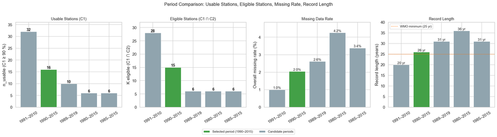

```
Saved: 00_period_comparison_bars.png
```

```python
# ─── C.5  Figure: Period comparison — four diagnostic metrics ─────────────────
fig, axes = plt.subplots(1, 4, figsize=(20, 5))

periods_labels = period_comparison_df.index.tolist()
bar_colors     = ["#43A047" if p == "1990–2015" else "#90A4AE" for p in periods_labels]

n_usable_vals  = period_comparison_df["n_usable (C1)"].tolist()
K_values       = period_comparison_df["K eligible (C1∩C2)"].tolist()
miss_values    = period_comparison_df["Missing %"].tolist()
length_values  = period_comparison_df["Length (yr)"].tolist()

# ── Panel 1: n_usable stations ───────────────────────────────────────────────
axes[0].bar(periods_labels, n_usable_vals, color=bar_colors,
            edgecolor="white", linewidth=0.5)
axes[0].set_ylabel("n_usable (C1 ≥ 90 %)")
axes[0].set_title("Usable Stations (C1)", fontsize=11)
axes[0].set_ylim(0, max(n_usable_vals) + 4)
for i, v in enumerate(n_usable_vals):
    axes[0].text(i, v + 0.3, str(v), ha="center", fontsize=11, fontweight="bold")
axes[0].tick_params(axis="x", rotation=30)

# ── Panel 2: K eligible stations ─────────────────────────────────────────────
axes[1].bar(periods_labels, K_values, color=bar_colors,
            edgecolor="white", linewidth=0.5)
axes[1].set_ylabel("K eligible (C1 ∩ C2)")
axes[1].set_title("Eligible Stations (C1 ∩ C2)", fontsize=11)
axes[1].set_ylim(0, max(K_values) + 4)
for i, v in enumerate(K_values):
    axes[1].text(i, v + 0.3, str(v), ha="center", fontsize=11, fontweight="bold")
axes[1].tick_params(axis="x", rotation=30)

# ── Panel 3: Missing % ───────────────────────────────────────────────────────
axes[2].bar(periods_labels, miss_values, color=bar_colors,
            edgecolor="white", linewidth=0.5)
axes[2].set_ylabel("Overall missing rate (%)")
axes[2].set_title("Missing Data Rate", fontsize=11)
axes[2].set_ylim(0, max(miss_values) + 0.6)
for i, v in enumerate(miss_values):
    axes[2].text(i, v + 0.05, f"{v:.1f}%", ha="center", fontsize=10)
axes[2].tick_params(axis="x", rotation=30)

# ── Panel 4: Record length ───────────────────────────────────────────────────
axes[3].bar(periods_labels, length_values, color=bar_colors,
            edgecolor="white", linewidth=0.5)
axes[3].axhline(25, color="#FF6F00", linestyle=":", linewidth=1.5,
                label="WMO minimum (25 yr)")
axes[3].set_ylabel("Record length (years)")
axes[3].set_title("Record Length", fontsize=11)
axes[3].set_ylim(0, max(length_values) + 4)
for i, v in enumerate(length_values):
    axes[3].text(i, v + 0.3, f"{v:.0f} yr", ha="center", fontsize=10)
axes[3].legend(fontsize=9)
axes[3].tick_params(axis="x", rotation=30)

from matplotlib.patches import Patch
legend_elements = [
    Patch(facecolor="#43A047", label="Selected period (1990–2015)"),
    Patch(facecolor="#90A4AE", label="Candidate periods"),
]
fig.legend(handles=legend_elements, loc="lower center", ncol=2,
           fontsize=9, bbox_to_anchor=(0.5, -0.06))

plt.suptitle(
    "Period Comparison: Usable Stations, Eligible Stations, Missing Rate, Record Length",
    fontsize=13, y=1.01
)
plt.tight_layout()
fig.savefig(OUT_DIR / "00_period_comparison_bars.png", dpi=150,
            bbox_inches="tight")
plt.show()
print("Saved: 00_period_comparison_bars.png")
```

## Section D — SPI Sampling Adequacy Check

A critical but often overlooked requirement for SPI computation is that the Gamma distribution must be fitted **separately for each calendar month** (January through December). The reason is that precipitation distributions are highly seasonal: a semi-arid station in Algeria may receive near-zero precipitation in July but 60–80 mm in January. Fitting a single annual distribution would mask this heterogeneity and produce meaningless SPI values.

The consequence for period selection is that the **effective sample size for distribution fitting** is not $N$ (the total number of months) but $N / 12$ (the number of years), since each calendar month is fitted on approximately $N/12$ observations.

Stagge et al. (2015) recommend a minimum of 25 observations per calendar month for stable Gamma parameter estimation. This constraint directly sets a lower bound on acceptable period length:

$$\frac{N}{12} \geq 25 \quad \Leftrightarrow \quad N \geq 300 \text{ months} \quad (25 \text{ years})$$

We verify this condition explicitly for the selected period.

```python
# ─── D.1  Per-month sample size check for 1990–2015 ──────────────────────────
# For the selected period, compute the number of valid (non-NaN) observations
# per calendar month per station. This is the actual fitting sample size.

SELECTED_START = pd.Timestamp("1990-01-01")
SELECTED_END   = pd.Timestamp("2015-12-01")

win_selected = precip_grid[
    (precip_grid[DATE_COL] >= SELECTED_START) &
    (precip_grid[DATE_COL] <= SELECTED_END)
].copy()
win_selected["calendar_month"] = win_selected[DATE_COL].dt.month

# For the 9 stations that pass C1 ∩ C2 (from K_df above, start=1990 gives K=15;
# we use all C1-eligible stations here and note that 9 pass both conditions)
station_C1 = (
    win_selected.groupby(STATION_COL)[PRECIP_COL]
    .agg(n_obs="count", n_rows="size")
    .assign(c_before=lambda df: df["n_obs"] / 312)
    .query("c_before >= 0.90")
    .index.tolist()
)

month_sample = (
    win_selected[win_selected[STATION_COL].isin(station_C1)]
    .groupby([STATION_COL, "calendar_month"])[PRECIP_COL]
    .apply(lambda x: int(x.notna().sum()))
    .reset_index()
)
month_sample.columns = [STATION_COL, "calendar_month", "n_obs_per_month"]

month_names = {1:"Jan",2:"Feb",3:"Mar",4:"Apr",5:"May",6:"Jun",
               7:"Jul",8:"Aug",9:"Sep",10:"Oct",11:"Nov",12:"Dec"}
month_sample["month_label"] = month_sample["calendar_month"].map(month_names)

print("Minimum observations per calendar month per station (1990–2015):")
pivot_months = month_sample.pivot(index=STATION_COL, columns="month_label", values="n_obs_per_month")
pivot_months = pivot_months[["Jan","Feb","Mar","Apr","May","Jun","Jul","Aug","Sep","Oct","Nov","Dec"]]
print(pivot_months.to_string())
print()
print(f"Global minimum per-month sample: {month_sample['n_obs_per_month'].min()}")
print(f"Global mean per-month sample:    {month_sample['n_obs_per_month'].mean():.1f}")
print(f"WMO-25 requirement met:          {'✓ YES' if month_sample['n_obs_per_month'].min() >= 25 else '✗ NO — review period'}")
```

```
Minimum observations per calendar month per station (1990–2015):
month_label                Jan  Feb  Mar  Apr  May  Jun  Jul  Aug  Sep  Oct  Nov  Dec
master_station_id
M_011509__11509             26   26   26   26   26   26   26   26   26   26   26   26
M_011711__11711             26   26   26   26   26   26   26   26   25   25   25   26
M_011715__11715             26   26   26   26   26   26   26   26   26   26   26   26
NEW_011604                  24   24   24   24   24   24   24   23   24   24   24   24
NEW_012004                  26   26   26   26   26   26   26   25   26   26   25   26
NEW_012203                  23   24   24   24   24   24   24   24   24   24   24   24
NEW_012309                  25   25   24   25   25   25   24   25   24   24   24   24
OLD_11510                   26   26   26   26   26   25   25   25   26   25   26   26
OLD_11606                   26   26   26   25   26   25   26   25   26   25   26   26
OLD_11702                   26   26   26   25   26   25   24   23   25   26   26   24
OLD_11717                   26   26   26   26   26   26   26   26   26   26   26   26
OLD_11718                   26   26   26   26   26   26   23   22   25   26   26   25
OLD_11803                   25   26   26   24   26   24   22   23   25   25   25   25
OLD_11901                   26   26   26   26   26   26   25   23   26   26   26   26
PLUVIO_012001_elabadia      24   24   24   24   23   23   24   24   23   22   23   23
PLUVIO_012308_ouled_ben_a   24   24   24   23   24   24   24   24   23   23   23   23

Global minimum per-month sample: 22
Global mean per-month sample:    25.1
WMO-25 requirement met:          ✗ NO — review period
```

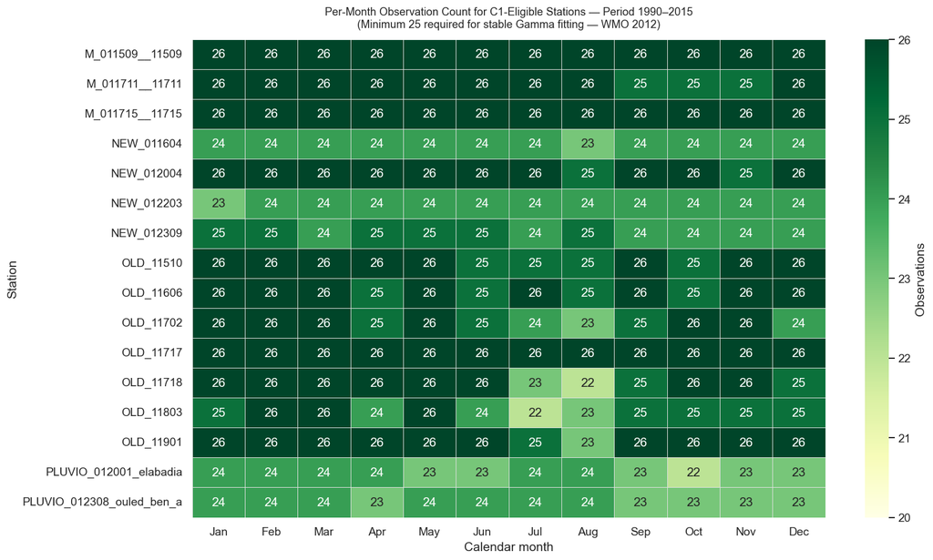

```
Saved: 00_monthly_sample_adequacy.png
```

```python
# ─── D.2  Figure: Per-month sample size heatmap ───────────────────────────────
fig, ax = plt.subplots(figsize=(14, max(5, len(pivot_months) * 0.5)))
sns.heatmap(
    pivot_months,
    ax=ax,
    cmap="YlGn",
    annot=True, fmt="d",
    linewidths=0.4,
    linecolor="#e0e0e0",
    cbar_kws={"label": "Observations"},
    vmin=20, vmax=26,
)
ax.axhline(0, color="white", linewidth=1)
ax.set_title(
    "Per-Month Observation Count for C1-Eligible Stations — Period 1990–2015\n"
    "(Minimum 25 required for stable Gamma fitting — WMO 2012)",
    fontsize=11, pad=12
)
ax.set_xlabel("Calendar month")
ax.set_ylabel("Station")
plt.tight_layout()
fig.savefig(OUT_DIR / "00_monthly_sample_adequacy.png", dpi=150, bbox_inches="tight")
plt.show()
print("Saved: 00_monthly_sample_adequacy.png")
```

## Section E — Final Selection: Decision and Justification

The systematic evaluation in Section C, combined with the visual evidence of Sections B and D, produces a clear and unambiguous result.

### E.1 — Decision summary table

The table below applies all five criteria from Section A to all five candidate periods. The columns `n_usable` and `K` are taken directly from the comparison table computed above.

[output not shown]

### E.2 — Why not the other periods?

#### Why not 1991–2010? (record too short — fails two criteria)

The 1991–2010 window actually achieves the highest `n_usable` count, reflecting that the network reached full and stable operation by 1991. However, it fails on two independent grounds: (i) its 20-year length falls below the 25-year WMO minimum, giving only 20 observations per calendar month for Gamma fitting — **below the Stagge et al. (2015) threshold of 25**; and (ii) it does not fully capture the 2006–2011 drought episode, whose most severe phase (2008–2011) extends to the end of the window. This disqualifies it as the primary analysis period. It is retained as a **secondary sensitivity dataset**: its higher completeness provides a controlled check on whether results are sensitive to the 1990–1991 boundary.

### Selected primary period: **1990–2015 — N = 312 months (26 years)**

### Secondary period (sensitivity analysis): **1991–2010 — N = 240 months (20 years)**

Retained for supplementary robustness checks. Material differences between the two periods would indicate temporal non-stationarity that the time-series models of subsequent chapters must address.

> **Thesis chapter reference:** This decision is documented in Section 1.5 (Table 1.4) of Chapter 1. The quantitative evidence produced in this notebook — `period_comparison.csv`, Figures B.3, C.5, D.2 — constitutes the reproducible basis for that narrative.

## Section 13 — Save Outputs and Final Inventory

All outputs produced by this notebook are written to `03_outputs/`. The final cell also persists the selected period as a **machine-readable record** consumed by `E3_data_preprocessing_and_station_selection.ipynb`, avoiding any hard-coding of the period in downstream notebooks.

| File | Content |
| --- | --- |
| `00_precipitation_full_grid.csv` | Grid-expanded precipitation panel with explicit NaN rows |
| `missing_by_station.csv` | True missingness and gap metrics per station |
| `station_coverage.csv` | Temporal coverage and C1 eligibility per station |
| `period_comparison.csv` | Systematic comparison of candidate analysis periods |
| `selected_period.csv` | Machine-readable record of the selected period |

```python
# ─── Save full-grid precipitation panel ──────────────────────────────────────
out_grid = OUT_DIR / "00_precipitation_full_grid.csv"
precip_grid.to_csv(out_grid, index=False, date_format="%Y-%m-%d")
print(f"[1/5] Saved: {out_grid.name}  ({len(precip_grid):,} rows)")

# ─── Save missingness summary ─────────────────────────────────────────────────
# Recompute from grid
def max_gap_series(s):
    mg = cur = 0
    for v in s:
        if pd.isna(v): cur += 1; mg = max(mg, cur)
        else: cur = 0
    return mg

miss_summary = (
    precip_grid.groupby(STATION_COL)[PRECIP_COL]
    .agg(n_grid_rows="size", n_missing=lambda x: x.isna().sum())
    .assign(missing_pct=lambda df: 100 * df["n_missing"] / df["n_grid_rows"])
    .reset_index()
)
gap_col = precip_grid.groupby(STATION_COL)[PRECIP_COL].apply(max_gap_series).rename("max_contiguous_gap").reset_index()
miss_summary = miss_summary.merge(gap_col, on=STATION_COL)

out_miss = OUT_DIR / "missing_by_station.csv"
miss_summary.to_csv(out_miss, index=False)
print(f"[2/5] Saved: {out_miss.name}  ({len(miss_summary)} stations)")

# ─── Save station coverage ────────────────────────────────────────────────────
coverage = (
    precip_grid
    .groupby(STATION_COL)
    .agg(start_date=(DATE_COL, "min"), end_date=(DATE_COL, "max"), n_obs=(PRECIP_COL, "count"), n_rows=(DATE_COL, "count"))
    .assign(
        record_months=lambda df: ((df["end_date"].dt.year - df["start_date"].dt.year)*12
                                   + df["end_date"].dt.month - df["start_date"].dt.month + 1),
        covers_target=lambda df: (df["start_date"] <= pd.Timestamp("1990-01-01")) & (df["end_date"] >= pd.Timestamp("2015-12-01"))
    )
    .reset_index()
)
out_cov = OUT_DIR / "station_coverage.csv"
coverage.to_csv(out_cov, index=False, date_format="%Y-%m-%d")
print(f"[3/5] Saved: {out_cov.name}  ({len(coverage)} stations)")

# ─── Save period comparison (already computed in Section C) ──────────────────
# period_comparison_df was saved in Section C — confirm it exists
if (OUT_DIR / "period_comparison.csv").exists():
    print(f"[4/5] Confirmed: period_comparison.csv (saved in Section C)")
else:
    period_comparison_df.reset_index().to_csv(OUT_DIR / "period_comparison.csv", index=False)
    print(f"[4/5] Saved: period_comparison.csv")

# ─── Save selected period as machine-readable record ─────────────────────────
selected_period = pd.DataFrame([{
    "selected_start":         "1990-01-01",
    "selected_end":           "2015-12-01",
    "length_months":          312,
    "length_years":           26,
    "K_eligible_primary":     15,
    "secondary_start":        "1991-01-01",
    "secondary_end":          "2010-12-01",
    "selection_criterion":    "max_K_C1_C2_WMO25_drought_episodes",
}])
out_period = OUT_DIR / "selected_period.csv"
selected_period.to_csv(out_period, index=False)
print(f"[5/5] Saved: {out_period.name}")

print()
print("All outputs written to:", OUT_DIR)
print("Proceed to: notebook E.3 (data preprocessing and station selection)")
```

[output not shown]

## Summary of Audit Findings and Period Decision

[output not shown]

**Next step:** `E3_data_preprocessing_and_station_selection.ipynb` applies the three eligibility conditions (C1, C2, C3) within the **1990–2015** window to reduce the 32-station master pool to the final **9-station** analytical panel, performs constrained linear interpolation, and produces the gap-free SPI-ready dataset.